← Back to portfolio

VMS · FISHERIES MANAGEMENT · SPATIAL ANALYSIS

# El Rincón: VMS patterns in a potential fisheries OECM case

This page presents a descriptive visualization of Argentine VMS records in and around El Rincón from 2005 to 2024. It extends the temporal comparison presented in Romero et al. (2025) across continuous October–March seasons, using a fixed spatial grid and the AER-2010 boundary.

Descriptive visualization of VMS records; not a compliance assessment.

## Regulatory timeline

El Rincón's protection was not a single measure — it was built up in stages.

2004

Initial seasonal closure

Acta CFP 53/2004 established a seasonal closure to protect reproductive concentrations of coastal demersal species in El Rincón.

2005-2008

Closure maintained and adjusted

Resolution CFP 7/2005 continued the closure from November 1 to February 28. Resolution CFP 15/2006 maintained the measure and subsequent amendments extended the closing date.

2009

Exceptional closure and spatial redesign

Resolution CFP 14/2009 added an extraordinary closure from August 1 to October 31, with midwater pelagic fishing excepted. Resolution CFP 27/2009 expanded the seasonal closure to October 1-March 31, revised its geography and established a surrounding restricted-effort area. Access restrictions based on vessel length were also introduced in 2009, ahead of the definitive 2010 redesign.

2010

Current AER framework

Resolution CFP 2/2010 consolidated the current federal framework for the seasonal closure in waters under national jurisdiction: bottom trawling is prohibited from October 1 to March 31, while provincial waters are governed through separate regulations. Outside the closure season, bottom trawling by vessels over 25 m is restricted within the AER, with specified historical exceptions for qualifying vessels up to 29 m. Vessels targeting pelagic species with midwater trawls are excluded from both provisions.

2025

Potential OECM case study

Romero et al. assessed El Rincón as a potential fisheries OECM case. This was an assessment exercise, not formal OECM recognition.

← SWIPE →

## Records inside the AER-2010 boundary, Oct-Mar

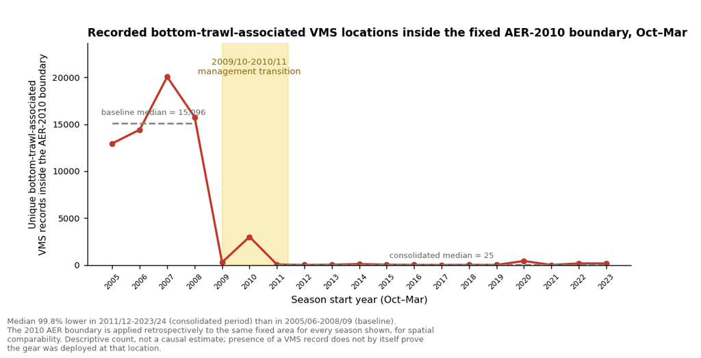

## What the pattern shows

- Records associated with bottom-trawl gear inside the fixed AER-2010 boundary fell from a median of about 15,100 per Oct-Mar season in 2005/06-2008/09 to a median of 25 in 2011/12-2023/24 — a decline of roughly 99.8%, measured over the same fixed area throughout the series.
- A separate sensitivity check added records from shrimp outrigger trawlers — a different gear category, evaluated separately — and found no material change to the estimated decline.

## Methods

This page extends the temporal comparison presented in Romero et al. (2025), using Argentine VMS records provided by the Undersecretariat of Fisheries and Aquaculture. Martínez Puljak et al. (2018) describes the administrative framework linking VMS positions to fishing declarations that underlies this dataset. The main series reports records associated with bottom-trawl gear; shrimp outrigger trawlers, recorded as a separate gear category, were compared separately as a sensitivity check. The AER-2010 boundary was applied consistently across the full 2005-2024 period using point-in-polygon classification, so the same fixed area is compared throughout the series. October-March seasons were reconstructed as continuous management cycles (for example, October-December 2005 plus January-March 2006 form the 2005/06 season). Records were aggregated to a 0.1° grid using the same classification thresholds for every season shown. Map layers are displayed in WGS 84 (EPSG:4326).